# RQ1: Tolerability

Sabrina Norwood

17 June, 2026

# Deviations from preregistration

- Tolerability is a 0/1 variable, and is analyzed appropriately as a logistic regression rather than negative binomial as misspecified in the prereg.

# Dependencies

```r
library(tidyverse)
library(broom)
library(emmeans)
library(flextable)
library(officer)
library(lme4)
library(knitr)
library(kableExtra)

dir.create("../reports/")
dir.create("../reports/results_rq1_tolerability/")
```

# Load data

```r
df_rq1 <- read_csv("../data/processed/data_processed_behavioral_data_dropout.csv") %>%
  mutate(condition = relevel(factor(condition), ref = "CCC"))
```

# Descriptive: dropout counts and rates per condition

```r
df_rq1_summary <- df_rq1 %>%
  group_by(condition) %>%
  summarise(
    n_total    = n(),
    n_dropout  = sum(dropout),
    n_complete = sum(dropout == 0),
    dropout_rate = round(n_dropout / n_total * 100, 1),
    .groups = "drop"
  )

df_rq1_summary |> kable() |> kable_classic()
```

| condition | n_total | n_dropout | n_complete | dropout_rate |
| --- | --- | --- | --- | --- |
| CCC | 415 | 275 | 140 | 66.3 |
| ABC | 387 | 251 | 136 | 64.9 |
| ACC | 430 | 288 | 142 | 67.0 |
| BCC | 409 | 288 | 121 | 70.4 |

```r
write_csv(df_rq1_summary, "../reports/results_rq1_tolerability/dropout_summary.csv")
```

# Weekly dropout: how many dropped out in each week

```r
df_weekly_dropout <- df_rq1 %>%
  filter(dropout == 1) %>%
  count(condition, last_week, name = "n_dropouts") |>
  pivot_wider(names_from = "condition",
              values_from = "n_dropouts",
              names_prefix = "n_dropouts_")

df_weekly_dropout |> kable() |> kable_classic()
```

| last_week | n_dropouts_CCC | n_dropouts_ABC | n_dropouts_ACC | n_dropouts_BCC |
| --- | --- | --- | --- | --- |
| 1 | 144 | 133 | 143 | 134 |
| 2 | 34 | 36 | 43 | 42 |
| 3 | 32 | 28 | 39 | 39 |
| 4 | 28 | 30 | 31 | 36 |
| 5 | 37 | 24 | 32 | 37 |

```r
write_csv(df_weekly_dropout, "../reports/results_rq1_tolerability/weekly_dropout_counts.csv")
```

## RQ1 model: binary logistic regression (dropout ~ condition)

Preregistration specified negative binomial but dropout is binary — logistic is the correct choice (confirmed by Hanna’s thesis).

```r
model_rq1 <- glm(dropout ~ 1 + condition,
                 data = df_rq1,
                 family = binomial(link = "logit"))

summary(model_rq1)
```

```
##
## Call:
## glm(formula = dropout ~ 1 + condition, family = binomial(link = "logit"),
##     data = df_rq1)
##
## Coefficients:
##              Estimate Std. Error z value Pr(>|z|)
## (Intercept)   0.67513    0.10382   6.503 7.89e-11 ***
## conditionABC -0.06233    0.14872  -0.419    0.675
## conditionACC  0.03200    0.14592   0.219    0.826
## conditionBCC  0.19204    0.15005   1.280    0.201
## ---
## Signif. codes:  0 '***' 0.001 '**' 0.01 '*' 0.05 '.' 0.1 ' ' 1
##
## (Dispersion parameter for binomial family taken to be 1)
##
##     Null deviance: 2077.8  on 1640  degrees of freedom
## Residual deviance: 2074.7  on 1637  degrees of freedom
## AIC: 2082.7
##
## Number of Fisher Scoring iterations: 4
```

```r
# Tidy results with odds ratios and 95% CIs
results_rq1 <- tidy(model_rq1, exponentiate = TRUE, conf.int = TRUE) %>%
  mutate(
    OR   = round(estimate, 3),
    CI   = paste0("[", round(conf.low, 3), ", ", round(conf.high, 3), "]"),
    p    = case_when(p.value < .001 ~ "< .001",
                     TRUE           ~ as.character(round(p.value, 3)))
  ) %>%
  select(Predictor = term, OR, `95% CI` = CI, p)

results_rq1 |> kable() |> kable_classic()
```

| Predictor | OR | 95% CI | p |
| --- | --- | --- | --- |
| (Intercept) | 1.964 | [1.606, 2.413] | < .001 |
| conditionABC | 0.940 | [0.702, 1.258] | 0.675 |
| conditionACC | 1.033 | [0.776, 1.375] | 0.826 |
| conditionBCC | 1.212 | [0.903, 1.627] | 0.201 |

```r
write_csv(results_rq1, "../reports/results_rq1_tolerability/model_rq1_results.csv")

# Model fit
chi_sq  <- model_rq1$null.deviance - model_rq1$deviance
df_diff <- model_rq1$df.null - model_rq1$df.residual
p_fit   <- pchisq(chi_sq, df = df_diff, lower.tail = FALSE)
r2_mcf  <- 1 - (logLik(model_rq1) / logLik(update(model_rq1, . ~ 1)))

cat(sprintf("\nModel fit: χ²(%d) = %.2f, p = %.3f, McFadden R² = %.3f\n",
            df_diff, chi_sq, p_fit, as.numeric(r2_mcf)))
```

```
##
## Model fit: χ²(3) = 3.08, p = 0.380, McFadden R² = 0.001
```

## Pairwise comparisons (all pairs)

```r
pairwise_rq1 <- emmeans(model_rq1, ~ condition) %>%
  contrast("pairwise", adjust = "none") %>%
  summary(infer = TRUE, type = "response") %>%
  as_tibble() %>%
  mutate(
    across(where(is.numeric), ~ round(.x, 3)),
    p = case_when(p.value < .001 ~ "< .001",
                  TRUE           ~ as.character(round(p.value, 3)))
  )

pairwise_rq1 |> kable() |> kable_classic()
```

| contrast | odds.ratio | SE | df | asymp.LCL | asymp.UCL | null | z.ratio | p.value | p |
| --- | --- | --- | --- | --- | --- | --- | --- | --- | --- |
| CCC / ABC | 1.064 | 0.158 | Inf | 0.795 | 1.424 | 1 | 0.419 | 0.675 | 0.675 |
| CCC / ACC | 0.969 | 0.141 | Inf | 0.728 | 1.289 | 1 | -0.219 | 0.826 | 0.826 |
| CCC / BCC | 0.825 | 0.124 | Inf | 0.615 | 1.107 | 1 | -1.280 | 0.201 | 0.201 |
| ABC / ACC | 0.910 | 0.135 | Inf | 0.681 | 1.216 | 1 | -0.638 | 0.523 | 0.523 |
| ABC / BCC | 0.775 | 0.118 | Inf | 0.576 | 1.044 | 1 | -1.675 | 0.094 | 0.094 |
| ACC / BCC | 0.852 | 0.127 | Inf | 0.636 | 1.141 | 1 | -1.073 | 0.283 | 0.283 |

```r
write_csv(pairwise_rq1, "../reports/results_rq1_tolerability/pairwise_rq1.csv")
```

## Estimated marginal means: predicted dropout probability per condition

```r
condition_order <- c("ABC", "ACC", "BCC", "CCC")

em_pred_rq1 <- emmeans(model_rq1, ~ condition, type = "response") |>
  summary(infer = TRUE) |>
  as_tibble() |>
  mutate(condition = factor(condition, levels = condition_order)) |>
  arrange(condition)

em_pred_rq1_table <- em_pred_rq1 |>
  mutate(
    `Pr(dropout)` = signif(prob, 3),
    `95% CI`      = paste0("[", signif(asymp.LCL, 3), ", ", signif(asymp.UCL, 3), "]")
  ) |>
  dplyr::select(Condition = condition, `Pr(dropout)`, `95% CI`)

em_pred_rq1_table |> kable() |> kable_classic()
```

| Condition | Pr(dropout) | 95% CI |
| --- | --- | --- |
| ABC | 0.649 | [0.6, 0.695] |
| ACC | 0.670 | [0.624, 0.713] |
| BCC | 0.704 | [0.658, 0.746] |
| CCC | 0.663 | [0.616, 0.707] |

```r
write_csv(em_pred_rq1_table, "../reports/results_rq1_tolerability/emmeans_rq1.csv")
```

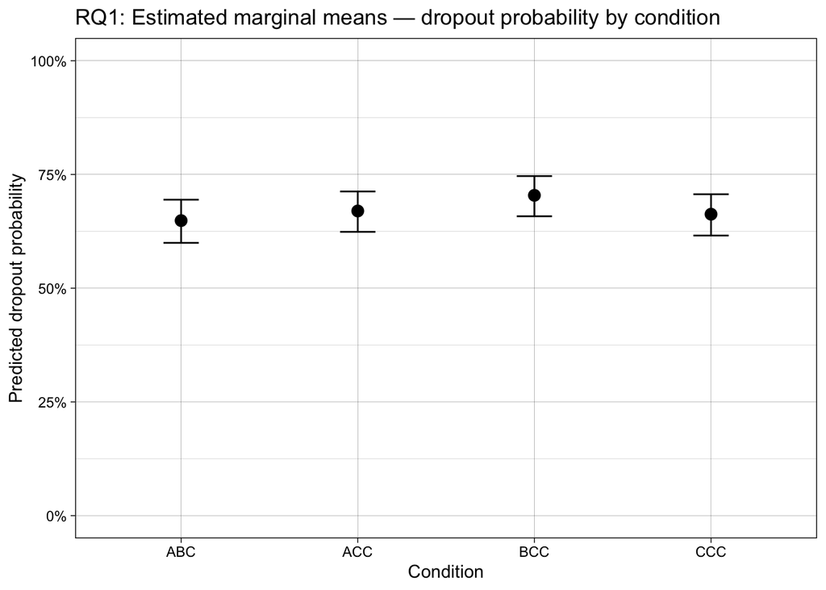

```r
p_em_rq1 <- ggplot(em_pred_rq1,
                   aes(x = condition, y = prob, ymin = asymp.LCL, ymax = asymp.UCL)) +
  geom_point(size = 3) +
  geom_errorbar(width = 0.2) +
  scale_y_continuous(labels = scales::percent_format(accuracy = 1),
                     limits = c(0, 1)) +
  labs(x = "Condition", y = "Predicted dropout probability",
       title = "RQ1: Estimated marginal means — dropout probability by condition") +
  theme_linedraw()

p_em_rq1
```

```r
ggsave("../reports/results_rq1_tolerability/emmeans_rq1_plot.png",
       p_em_rq1, width = 5, height = 4, dpi = 150)
```

## Word table

```r
doc <- read_docx() %>%
  body_add_par("RQ1: Logistic Regression — Dropout by Condition", style = "heading 1") %>%
  body_add_flextable(flextable(results_rq1) %>% autofit()) %>%
  body_add_par("", style = "Normal") %>%
  body_add_par("Estimated Marginal Means (predicted dropout probability)", style = "heading 2") %>%
  body_add_flextable(flextable(em_pred_rq1_table) %>% autofit()) %>%
  body_add_par("", style = "Normal") %>%
  body_add_par("Pairwise Comparisons (odds ratios)", style = "heading 2") %>%
  body_add_flextable(flextable(pairwise_rq1 %>%
                                 select(contrast, odds.ratio, SE, asymp.LCL, asymp.UCL, p)) %>%
                       autofit())

print(doc, target = "../reports/results_rq1_tolerability/results_rq1.docx")
```

# Non preregistered model: discrete-time dropout hazard

**Research question shift.** The preregistered RQ1 asks whether *condition assignment* affects total dropouts — an intention-to-treat (ITT) question at the level of the randomised arm. The non-preregistered model below reframes this to a **dose-response** question: does the *current delay length* (in seconds) raise the per-week dropout hazard, regardless of which condition produced that dose? This is a different scientific question — closer to the underlying mechanism the study cares about (do longer delays cause people to give up?).

**Why a hazard model.** The preregistered NB regression on per-condition dropout *counts* effectively has 4 data points (one per condition) and models no within-condition variation. The logistic model used above is a clear improvement, but still collapses 6 weeks of activity into a single bit per participant. A discrete-time hazard model preserves *when* people drop out: each participant contributes one row per week-at-risk, with a binary indicator for whether they dropped out that week.

**Why `delay_secs` instead of `condition`.** The covariate of interest is the current delay length in seconds (3s, 6s, or 10s), which varies by condition × week. Treating it as a continuous numeric predictor uses 1 df instead of 3, gaining power *if* the dose-response is approximately linear. `factor(week)` is included to absorb baseline weekly hazard (study fatigue, time-since-start), so the `delay_secs` coefficient captures the marginal effect of dose holding week constant. Note: in this hazard model, identification of `delay_secs` is largely between-subject (at any fixed week, a participant’s delay is determined by their condition); the within-subject component exists but is limited because the design only ever ramps delay up.

```r
# Person-period dataset: one row per participant × at-risk week.
# Dropout assumed to occur at the start of week (last_week + 1).
# Censored at week 6 if last_week == 6 (no dropout event).
# delay_secs derived from the same rule as Step 5 of data processing.
person_period <- df_rq1 %>%
  mutate(exit_week = if_else(dropout == 1L, last_week + 1L, 6L)) %>%
  rowwise() %>%
  mutate(week = list(seq_len(min(exit_week, 6L)))) %>%
  unnest(week) %>%
  ungroup() %>%
  mutate(
    dropped_out = as.integer(week == exit_week & dropout == 1L),
    delay_secs  = case_when(
      condition == "CCC"                  ~ 10,
      condition == "ABC" & week <= 2      ~ 3,
      condition == "ABC" & week <= 4      ~ 6,
      condition == "ABC"                  ~ 10,
      condition == "ACC" & week <= 2      ~ 3,
      condition == "ACC"                  ~ 10,
      condition == "BCC" & week <= 2      ~ 6,
      condition == "BCC"                  ~ 10
    )
  )

cat("Person-periods:", nrow(person_period),
    "\nDropout events:", sum(person_period$dropped_out), "\n")
```

```
## Person-periods: 6764
## Dropout events: 1102
```

```r
cat("Dropouts by week (should be 0 in week 1 by construction):\n")
```

```
## Dropouts by week (should be 0 in week 1 by construction):
```

```r
person_period |>
  group_by(week) |>
  summarise(n_dropped = sum(dropped_out)) |>
  kable() |> kable_classic()
```

| week | n_dropped |
| --- | --- |
| 1 | 0 |
| 2 | 554 |
| 3 | 155 |
| 4 | 138 |
| 5 | 125 |
| 6 | 130 |

```r
# Drop week 1: by construction it has zero dropout events (earliest possible
# exit_week is 2 because last_week >= 1 for anyone with data). Including it
# causes separation — the intercept is fit at -Inf and the week dummies blow
# up to compensate.
m_hazard <- glm(
  dropped_out ~ delay_secs + factor(week),
  family = binomial(link = "logit"),
  data   = filter(person_period, week >= 2)
)
summary(m_hazard)
```

```
##
## Call:
## glm(formula = dropped_out ~ delay_secs + factor(week), family = binomial(link = "logit"),
##     data = filter(person_period, week >= 2))
##
## Coefficients:
##                Estimate Std. Error z value Pr(>|z|)
## (Intercept)   -0.722535   0.104295  -6.928 4.27e-12 ***
## delay_secs     0.008775   0.016293   0.539     0.59
## factor(week)3 -1.150998   0.116535  -9.877  < 2e-16 ***
## factor(week)4 -1.106911   0.120663  -9.174  < 2e-16 ***
## factor(week)5 -1.042684   0.132278  -7.883 3.21e-15 ***
## factor(week)6 -0.787395   0.132478  -5.944 2.79e-09 ***
## ---
## Signif. codes:  0 '***' 0.001 '**' 0.01 '*' 0.05 '.' 0.1 ' ' 1
##
## (Dispersion parameter for binomial family taken to be 1)
##
##     Null deviance: 5334.5  on 5122  degrees of freedom
## Residual deviance: 5120.8  on 5117  degrees of freedom
## AIC: 5132.8
##
## Number of Fisher Scoring iterations: 4
```

```r
# signif() rounds to N significant figures (round() rounds to N decimal
# places, which is useless for very large or very small numbers).
results_hazard <- tidy(m_hazard, exponentiate = TRUE, conf.int = TRUE) %>%
  mutate(
    OR = round(estimate, 3),
    CI = paste0("[", round(conf.low, 3), ", ", round(conf.high, 3), "]"),
    p  = case_when(p.value < .001 ~ "< .001",
                   TRUE           ~ as.character(round(p.value, 3)))
  ) %>%
  dplyr::select(Predictor = term, OR, `95% CI` = CI, p)

results_hazard |> kable() |> kable_classic()
```

| Predictor | OR | 95% CI | p |
| --- | --- | --- | --- |
| (Intercept) | 0.486 | [0.395, 0.595] | < .001 |
| delay_secs | 1.009 | [0.977, 1.042] | 0.59 |
| factor(week)3 | 0.316 | [0.251, 0.397] | < .001 |
| factor(week)4 | 0.331 | [0.26, 0.418] | < .001 |
| factor(week)5 | 0.353 | [0.271, 0.456] | < .001 |
| factor(week)6 | 0.455 | [0.35, 0.589] | < .001 |

```r
write_csv(results_hazard, "../reports/results_rq1_tolerability/hazard_model_results.csv")

# Descriptive: weekly dropout rates (n_dropped / n_at_risk) per delay dose
hazard_by_dose <- person_period %>%
  group_by(delay_secs, week) %>%
  summarise(
    n_at_risk  = n(),
    n_dropped  = sum(dropped_out),
    hazard_pct = round(n_dropped / n_at_risk * 100, 1),
    .groups = "drop"
  )

hazard_by_dose |> kable() |> kable_classic()
```

| delay_secs | week | n_at_risk | n_dropped | hazard_pct |
| --- | --- | --- | --- | --- |
| 3 | 1 | 817 | 0 | 0.0 |
| 3 | 2 | 817 | 276 | 33.8 |
| 6 | 1 | 409 | 0 | 0.0 |
| 6 | 2 | 409 | 134 | 32.8 |
| 6 | 3 | 254 | 36 | 14.2 |
| 6 | 4 | 218 | 28 | 12.8 |
| 10 | 1 | 415 | 0 | 0.0 |
| 10 | 2 | 415 | 144 | 34.7 |
| 10 | 3 | 833 | 119 | 14.3 |
| 10 | 4 | 714 | 110 | 15.4 |
| 10 | 5 | 794 | 125 | 15.7 |
| 10 | 6 | 669 | 130 | 19.4 |

```r
write_csv(hazard_by_dose, "../reports/results_rq1_tolerability/weekly_hazard_by_dose.csv")

# Predicted dropout probability per delay dose (emmeans).
# The model is additive in delay_secs (no dose × week interaction), so the
# OR per second is constant; what varies usefully across doses is the
# absolute predicted weekly hazard. emmeans averages across the week
# dummies to give a marginal predicted probability at each delay level.
em_hazard_by_dose <- emmeans(
  m_hazard, ~ delay_secs,
  at   = list(delay_secs = c(3, 6, 10)),
  type = "response"
) |>
  summary(infer = TRUE) |>
  as_tibble() |>
  mutate(
    `Pr(dropout)` = signif(prob, 3),
    `95% CI`      = paste0("[", signif(asymp.LCL, 3), ", ",
                                signif(asymp.UCL, 3), "]")
  ) |>
  dplyr::select(`Delay (s)` = delay_secs, `Pr(dropout)`, `95% CI`)

em_hazard_by_dose |> kable() |> kable_classic()
```

| Delay (s) | Pr(dropout) | 95% CI |
| --- | --- | --- |
| 3 | 0.180 | [0.153, 0.212] |
| 6 | 0.184 | [0.167, 0.202] |
| 10 | 0.190 | [0.177, 0.203] |

```r
write_csv(em_hazard_by_dose,
          "../reports/results_rq1_tolerability/hazard_by_dose_emmeans.csv")
```

- Hypothesis test provided by the delay_secs parameter.

## Hazard-implied per-condition cumulative dropout

The hazard model predicts dropout *per week, per delay dose*. To put it on the same scale as the preregistered logistic (which predicts whole-study dropout per condition), we chain the per-week hazards using each condition’s actual delay schedule: cumulative dropout by Week 6 is $1 - \prod_{w=2}^{6}(1 - h(\text{delay}_w, w))$.

Neither model uses a random effect, so both estimates are already marginal (population-averaged) — no Jensen correction needed.

```r
# Each condition's delay schedule across the at-risk weeks (2..6).
condition_schedule <- tribble(
  ~condition, ~week, ~delay_secs,
  "ABC", 2,  3, "ABC", 3,  6, "ABC", 4,  6, "ABC", 5, 10, "ABC", 6, 10,
  "ACC", 2,  3, "ACC", 3, 10, "ACC", 4, 10, "ACC", 5, 10, "ACC", 6, 10,
  "BCC", 2,  6, "BCC", 3, 10, "BCC", 4, 10, "BCC", 5, 10, "BCC", 6, 10,
  "CCC", 2, 10, "CCC", 3, 10, "CCC", 4, 10, "CCC", 5, 10, "CCC", 6, 10
) |>
  mutate(week = factor(week, levels = 2:6))

# Design matrix in the model's parameterisation.
mm <- model.matrix(formula(m_hazard)[-2], data = condition_schedule)

# Point estimates: predicted per-week hazard → cumulative dropout per condition.
beta_hat <- coef(m_hazard)
condition_schedule$hazard <- plogis(as.numeric(mm %*% beta_hat))

cum_point <- condition_schedule |>
  group_by(condition) |>
  summarise(prob = 1 - prod(1 - hazard), .groups = "drop")

# Parametric bootstrap CIs (delta method awkward through the chained product).
set.seed(42)
n_sim     <- 2000
beta_sim  <- MASS::mvrnorm(n_sim, mu = beta_hat, Sigma = vcov(m_hazard))
cum_boot  <- apply(beta_sim, 1, function(b) {
  h <- plogis(as.numeric(mm %*% b))
  tapply(h, condition_schedule$condition, function(hs) 1 - prod(1 - hs))
})
ci <- t(apply(cum_boot, 1, quantile, probs = c(0.025, 0.975)))

em_hazard_by_condition <- tibble(
  condition = rownames(ci),
  prob      = cum_point$prob[match(condition, cum_point$condition)],
  ci_lower  = ci[, 1],
  ci_upper  = ci[, 2]
) |>
  mutate(condition = factor(condition, levels = condition_order)) |>
  arrange(condition)

em_hazard_by_condition_table <- em_hazard_by_condition |>
  mutate(
    `Pr(dropout)` = signif(prob, 3),
    `95% CI`      = paste0("[", signif(ci_lower, 3), ", ",
                                signif(ci_upper, 3), "]")
  ) |>
  dplyr::select(Condition = condition, `Pr(dropout)`, `95% CI`)

em_hazard_by_condition_table |> kable() |> kable_classic()
```

| Condition | Pr(dropout) | 95% CI |
| --- | --- | --- |
| ABC | 0.667 | [0.636, 0.696] |
| ACC | 0.670 | [0.646, 0.695] |
| BCC | 0.673 | [0.651, 0.697] |
| CCC | 0.677 | [0.65, 0.707] |

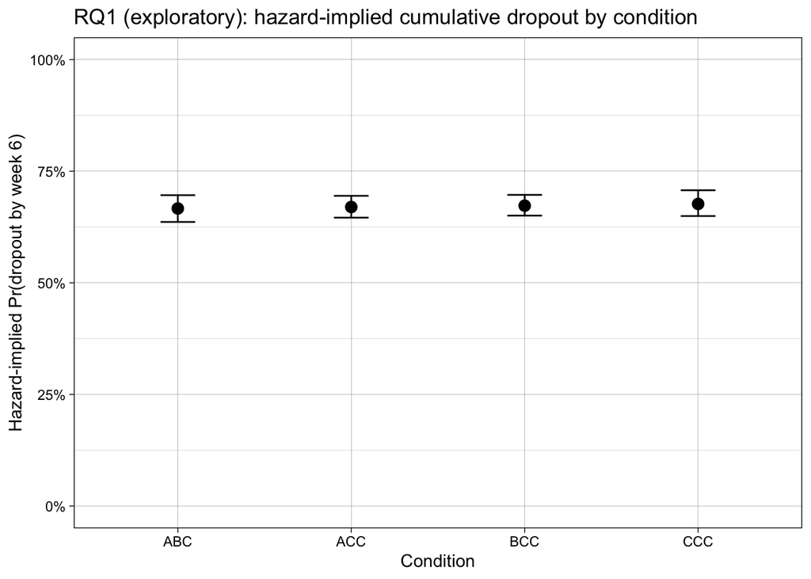

```r
write_csv(em_hazard_by_condition_table,
          "../reports/results_rq1_tolerability/hazard_by_condition_emmeans.csv")

# Standalone plot in the same style as the preregistered EMM plot.
p_hazard_by_condition <- ggplot(em_hazard_by_condition,
  aes(x = condition, y = prob, ymin = ci_lower, ymax = ci_upper)) +
  geom_point(size = 3) +
  geom_errorbar(width = 0.2) +
  scale_y_continuous(labels = scales::percent_format(accuracy = 1),
                     limits = c(0, 1)) +
  labs(x = "Condition", y = "Hazard-implied Pr(dropout by week 6)",
       title = "RQ1 (exploratory): hazard-implied cumulative dropout by condition") +
  theme_linedraw()

p_hazard_by_condition
```

```r
ggsave("../reports/results_rq1_tolerability/hazard_by_condition_plot.png",
       p_hazard_by_condition, width = 5, height = 4, dpi = 150)
```

## Combined comparison: Preregistered vs Exploratory at Week 6

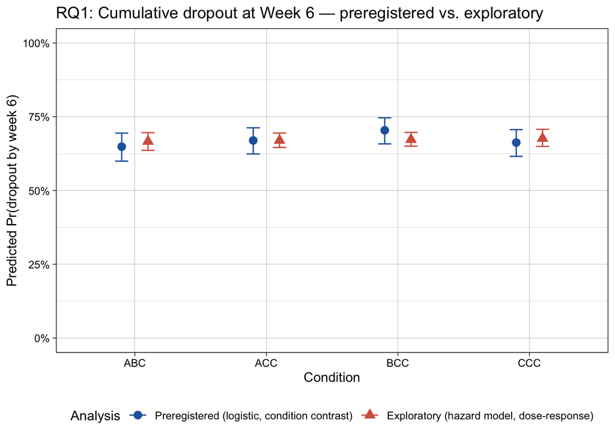

```r
dropout_combined <- bind_rows(
  em_pred_rq1 |>
    mutate(
      condition = factor(condition, levels = condition_order),
      estimate  = prob,
      lower     = asymp.LCL,
      upper     = asymp.UCL,
      Analysis  = "Preregistered (logistic, condition contrast)"
    ),
  em_hazard_by_condition |>
    mutate(
      estimate = prob,
      lower    = ci_lower,
      upper    = ci_upper,
      Analysis = "Exploratory (hazard model, dose-response)"
    )
) |>
  mutate(Analysis = factor(Analysis,
                           levels = c("Preregistered (logistic, condition contrast)",
                                      "Exploratory (hazard model, dose-response)")))

p_dropout_combined <- ggplot(dropout_combined,
  aes(x = condition, y = estimate, ymin = lower, ymax = upper,
      colour = Analysis, shape = Analysis, group = Analysis)) +
  geom_point(size = 3, position = position_dodge(0.4)) +
  geom_errorbar(width = 0.2, position = position_dodge(0.4)) +
  scale_y_continuous(labels = scales::percent_format(accuracy = 1),
                     limits = c(0, 1)) +
  scale_colour_manual(values = c("Preregistered (logistic, condition contrast)"   = "#2166ac",
                                 "Exploratory (hazard model, dose-response)"  = "#d6604d")) +
  scale_shape_manual(values  = c("Preregistered (logistic, condition contrast)"   = 16,
                                 "Exploratory (hazard model, dose-response)"  = 17)) +
  labs(x = "Condition", y = "Predicted Pr(dropout by week 6)",
       title = "RQ1: Cumulative dropout at Week 6 — preregistered vs. exploratory",
       colour = "Analysis", shape = "Analysis") +
  theme_linedraw() +
  theme(legend.position = "bottom")

p_dropout_combined
```

```r
ggsave("../reports/results_rq1_tolerability/combined_emm_dropout.png",
       p_dropout_combined, width = 6, height = 5, dpi = 150)
```